# Lab 6: ML Workflows

Author

Hanna Velicer

## Setting up the Lab

### Loading in necessary libraries

```r
library(tidyverse)
library(tidymodels)
library(powerjoin)
library(glue)
library(vip)
library(baguette)
```

### Data Download

```r
root  <- 'https://gdex.ucar.edu/dataset/camels/file'
download.file('https://gdex.ucar.edu/dataset/camels/file/camels_attributes_v2.0.pdf',
              'data/camels_attributes_v2.0.pdf')
```

### Basin Characteristics

```r
types <- c("clim", "geol", "soil", "topo", "vege", "hydro")
remote_files  <- glue('{root}/camels_{types}.txt')
local_files   <- glue('data/camels_{types}.txt')
walk2(remote_files, local_files, download.file, quiet = TRUE)
camels <- map(local_files, read_delim, show_col_types = FALSE)
camels <- power_full_join(camels ,by = 'gauge_id')
```

## Question 1

`zero_q_freq` represents the frequency of days where Q = 0 mm/day (as a %). The Q variable represents daily discharge.

### Exploratory Data Analysis

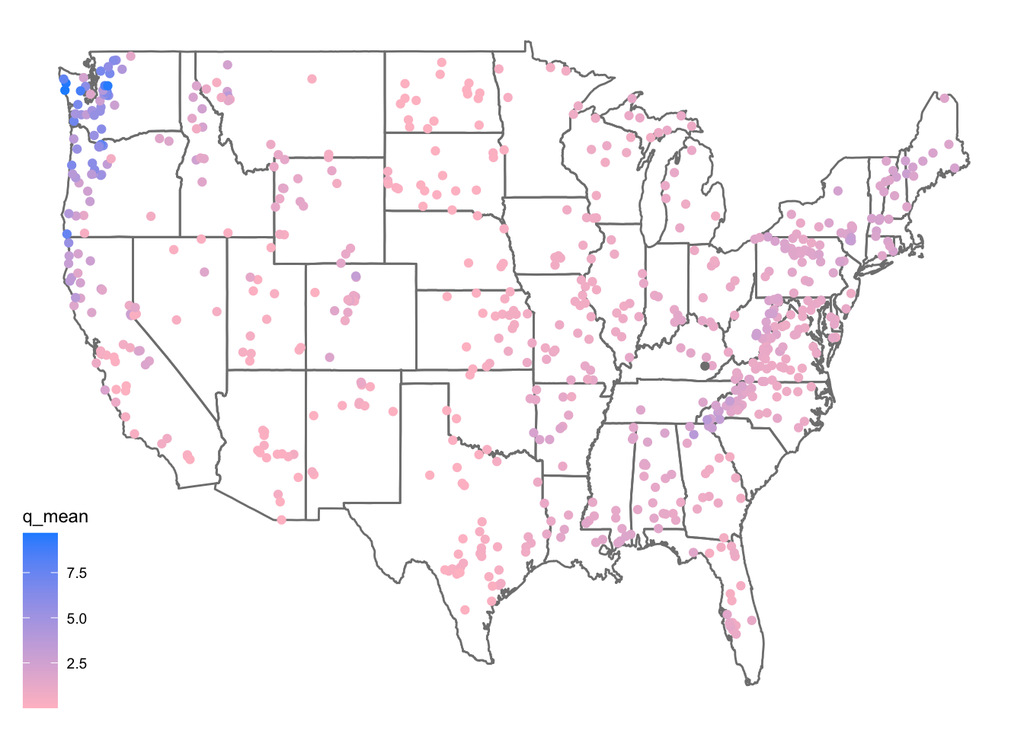

```r
library(ggpubr)

ggplot(data = camels, aes(x = gauge_lon, y = gauge_lat)) +
  borders("state", colour = "gray50") +
  geom_point(aes(color = q_mean)) +
  scale_color_gradient(low = "pink", high = "dodgerblue") +
  ggthemes::theme_map()
```

## Question 2

### Maps of the sites

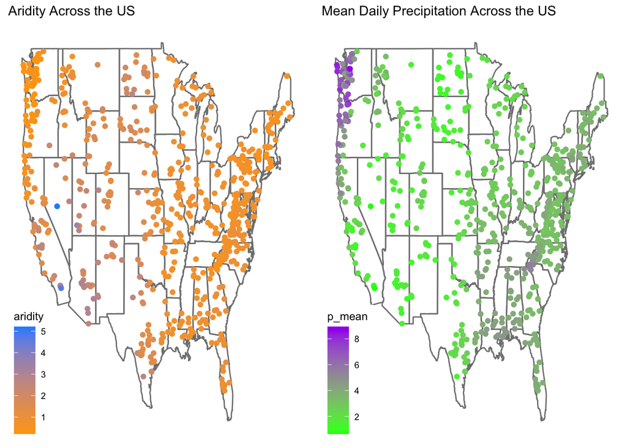

```r
plot1 <- ggplot(data = camels, aes(x = gauge_lon, y = gauge_lat)) +
  borders("state", colour = "gray50") +
  geom_point(aes(color = aridity)) +
  scale_color_gradient(low = "orange", high = "dodgerblue") +
  labs(x = "Longitude", y = "Latitude", title = "Aridity Across the US") +
  ggthemes::theme_map()

plot2 <- p2 <- ggplot(data = camels, aes(x = gauge_lon, y = gauge_lat)) +
  borders("state", colour = "gray50") +
  geom_point(aes(color = p_mean)) +
  scale_color_gradient(low = "green", high = "purple") +
  labs(x = "Longitude", y = "Latitude", title = "Mean Daily Precipitation Across the US") +
  ggthemes::theme_map()

ggarrange(plot1, plot2)
```

### Model Preparation

```r
camels %>%
  select(aridity, p_mean, q_mean) %>%
  drop_na() %>%
  cor()
```

```
           aridity     p_mean     q_mean
aridity  1.0000000 -0.7550090 -0.5817771
p_mean  -0.7550090  1.0000000  0.8865757
q_mean  -0.5817771  0.8865757  1.0000000
```

### Visual EDA

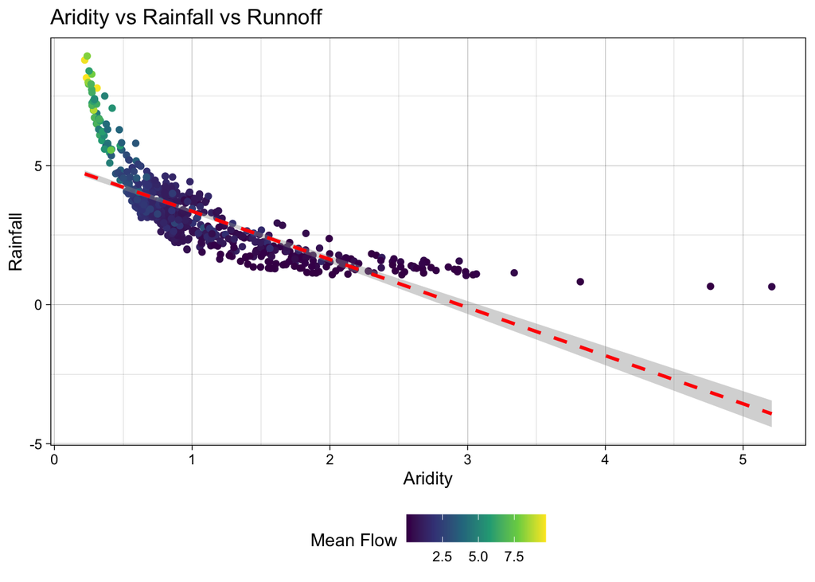

```r
# XY plot of aridity and rainfall
ggplot(camels, aes(x = aridity, y = p_mean)) +
  geom_point(aes(color = q_mean)) +
  geom_smooth(method = "lm", color = "red", linetype = 2) +
  scale_color_viridis_c() +
  theme_linedraw() +
  theme(legend.position = "bottom") +
  labs(title = "Aridity vs Rainfall vs Runnoff",
       x = "Aridity",
       y = "Rainfall",
       color = "Mean Flow")
```

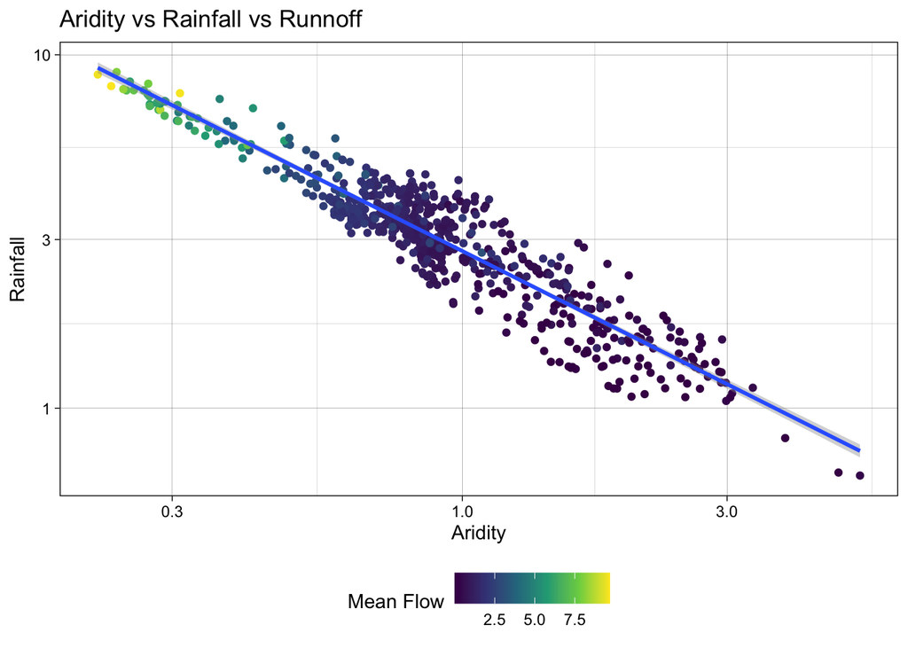

```r
# Testing a transformation
ggplot(camels, aes(x = aridity, y = p_mean)) +
  geom_point(aes(color = q_mean)) +
  geom_smooth(method = "lm") +
  scale_color_viridis_c() +
  # Apply log transformations to the x and y axes
  scale_x_log10() +
  scale_y_log10() +
  theme_linedraw() +
  theme(legend.position = "bottom") +
  labs(title = "Aridity vs Rainfall vs Runnoff",
       x = "Aridity",
       y = "Rainfall",
       color = "Mean Flow")
```

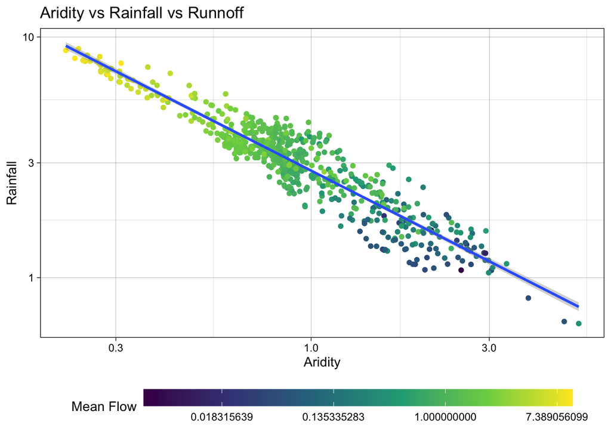

```r
# Visualize how log transform benefits the q_mean data
ggplot(camels, aes(x = aridity, y = p_mean)) +
  geom_point(aes(color = q_mean)) +
  geom_smooth(method = "lm") +
  scale_color_viridis_c(trans = "log") +
  scale_x_log10() +
  scale_y_log10() +
  theme_linedraw() +
  theme(legend.position = "bottom",
        # Expand the legend width ...
        legend.key.width = unit(2.5, "cm"),
        legend.key.height = unit(.5, "cm")) +
  labs(title = "Aridity vs Rainfall vs Runnoff",
       x = "Aridity",
       y = "Rainfall",
       color = "Mean Flow")
```

### Model Building

```r
# Splitting the data
set.seed(123)

camels <- camels %>%
  mutate(logQmean = log(q_mean))

camels_split <- initial_split(camels, prop = 0.8)
camels_train <- training(camels_split)
camels_test  <- testing(camels_split)

camels_cv <- vfold_cv(camels_train, v = 10)

# Preprocessor: recipe
rec <-  recipe(logQmean ~ aridity + p_mean, data = camels_train) %>%
  step_log(all_predictors()) %>%
  step_interact(terms = ~ aridity:p_mean) %>%
  step_naomit(all_predictors(), all_outcomes())

# Naive base lm approach
baked_data <- prep(rec, camels_train) %>%
  bake(new_data = NULL)

lm_base <- lm(logQmean ~ aridity * p_mean, data = baked_data)
summary(lm_base)
```

```
Call:
lm(formula = logQmean ~ aridity * p_mean, data = baked_data)

Residuals:
     Min       1Q   Median       3Q      Max
-2.91162 -0.21601 -0.00716  0.21230  2.85706

Coefficients:
               Estimate Std. Error t value Pr(>|t|)
(Intercept)    -1.77586    0.16365 -10.852  < 2e-16 ***
aridity        -0.88397    0.16145  -5.475 6.75e-08 ***
p_mean          1.48438    0.15511   9.570  < 2e-16 ***
aridity:p_mean  0.10484    0.07198   1.457    0.146
---
Signif. codes:  0 '***' 0.001 '**' 0.01 '*' 0.05 '.' 0.1 ' ' 1

Residual standard error: 0.5696 on 531 degrees of freedom
Multiple R-squared:  0.7697,    Adjusted R-squared:  0.7684
F-statistic: 591.6 on 3 and 531 DF,  p-value: < 2.2e-16
```

```r
summary(lm(logQmean ~ aridity + p_mean + aridity_x_p_mean, data = baked_data))
```

```
Call:
lm(formula = logQmean ~ aridity + p_mean + aridity_x_p_mean,
    data = baked_data)

Residuals:
     Min       1Q   Median       3Q      Max
-2.91162 -0.21601 -0.00716  0.21230  2.85706

Coefficients:
                 Estimate Std. Error t value Pr(>|t|)
(Intercept)      -1.77586    0.16365 -10.852  < 2e-16 ***
aridity          -0.88397    0.16145  -5.475 6.75e-08 ***
p_mean            1.48438    0.15511   9.570  < 2e-16 ***
aridity_x_p_mean  0.10484    0.07198   1.457    0.146
---
Signif. codes:  0 '***' 0.001 '**' 0.01 '*' 0.05 '.' 0.1 ' ' 1

Residual standard error: 0.5696 on 531 degrees of freedom
Multiple R-squared:  0.7697,    Adjusted R-squared:  0.7684
F-statistic: 591.6 on 3 and 531 DF,  p-value: < 2.2e-16
```

```r
# Correct Version: prep -> bake -> predict
test_data <-  bake(prep(rec), new_data = camels_test)
test_data$lm_pred <- predict(lm_base, newdata = test_data)
```

### Model Evaluation: Statistical and Visual

```r
metrics(test_data, truth = logQmean, estimate = lm_pred)
```

```
# A tibble: 3 × 3
  .metric .estimator .estimate
  <chr>   <chr>          <dbl>
1 rmse    standard       0.583
2 rsq     standard       0.742
3 mae     standard       0.390
```

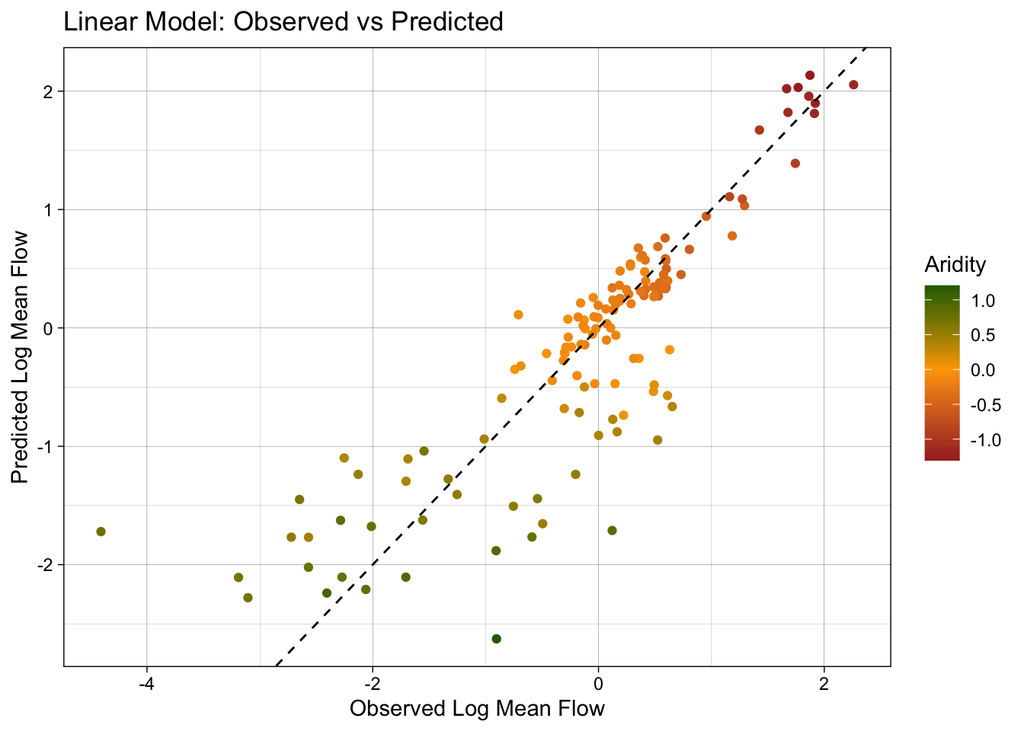

```r
# Linear model
ggplot(test_data, aes(x = logQmean, y = lm_pred, colour = aridity)) +
  scale_color_gradient2(low = "brown", mid = "orange", high = "darkgreen") +
  geom_point() +
  geom_abline(linetype = 2) +
  theme_linedraw() +
  labs(title = "Linear Model: Observed vs Predicted",
       x = "Observed Log Mean Flow",
       y = "Predicted Log Mean Flow",
       color = "Aridity")
```

```r
# Workflow
lm_model <- linear_reg() %>%
  set_engine("lm") %>%
  set_mode("regression")

lm_wf <- workflow() %>%
  add_recipe(rec) %>%
  add_model(lm_model) %>%
  fit(data = camels_train)

summary(extract_fit_engine(lm_wf))$coefficients
```

```
                   Estimate Std. Error    t value     Pr(>|t|)
(Intercept)      -1.7758557 0.16364755 -10.851710 6.463654e-25
aridity          -0.8839738 0.16144589  -5.475357 6.745512e-08
p_mean            1.4843771 0.15511117   9.569762 4.022500e-20
aridity_x_p_mean  0.1048449 0.07198145   1.456555 1.458304e-01
```

```r
summary(lm_base)$coefficients
```

```
                 Estimate Std. Error    t value     Pr(>|t|)
(Intercept)    -1.7758557 0.16364755 -10.851710 6.463654e-25
aridity        -0.8839738 0.16144589  -5.475357 6.745512e-08
p_mean          1.4843771 0.15511117   9.569762 4.022500e-20
aridity:p_mean  0.1048449 0.07198145   1.456555 1.458304e-01
```

```r
# Making predictions
lm_data <- augment(lm_wf, new_data = camels_test)
dim(lm_data)
```

```
[1] 135  61
```

```r
# Scatter plot
metrics(lm_data, truth = logQmean, estimate = .pred)
```

```
# A tibble: 3 × 3
  .metric .estimator .estimate
  <chr>   <chr>          <dbl>
1 rmse    standard       0.583
2 rsq     standard       0.742
3 mae     standard       0.390
```

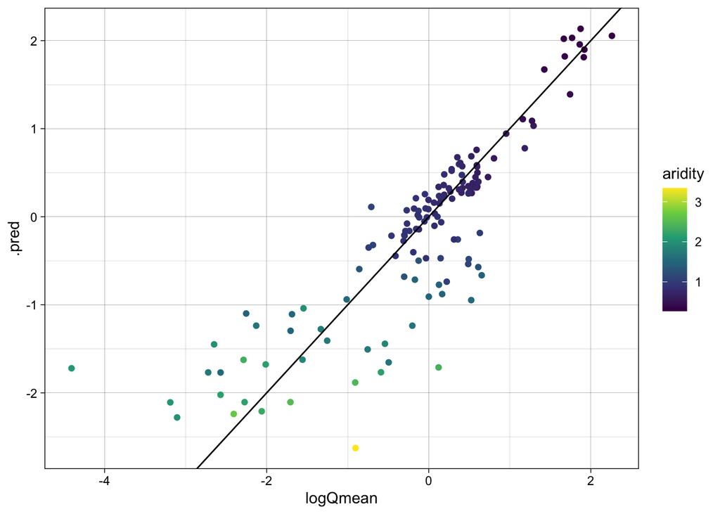

```r
ggplot(lm_data, aes(x = logQmean, y = .pred, colour = aridity)) +
  scale_color_viridis_c() +
  geom_point() +
  geom_abline() +
  theme_linedraw()
```

```r
# Switching it up
library(baguette)
rf_model <- rand_forest() %>%
  set_engine("ranger", importance = "impurity") %>%
  set_mode("regression")

rf_wf <- workflow() %>%
  add_recipe(rec) %>%
  add_model(rf_model) %>%
  fit(data = camels_train)

# Predictions
rf_data <- augment(rf_wf, new_data = camels_test)
dim(rf_data)
```

[output not shown]

```r
# Scatter plot pt. 2
metrics(rf_data, truth = logQmean, estimate = .pred)
```

```
# A tibble: 3 × 3
  .metric .estimator .estimate
  <chr>   <chr>          <dbl>
1 rmse    standard       0.592
2 rsq     standard       0.736
3 mae     standard       0.367
```

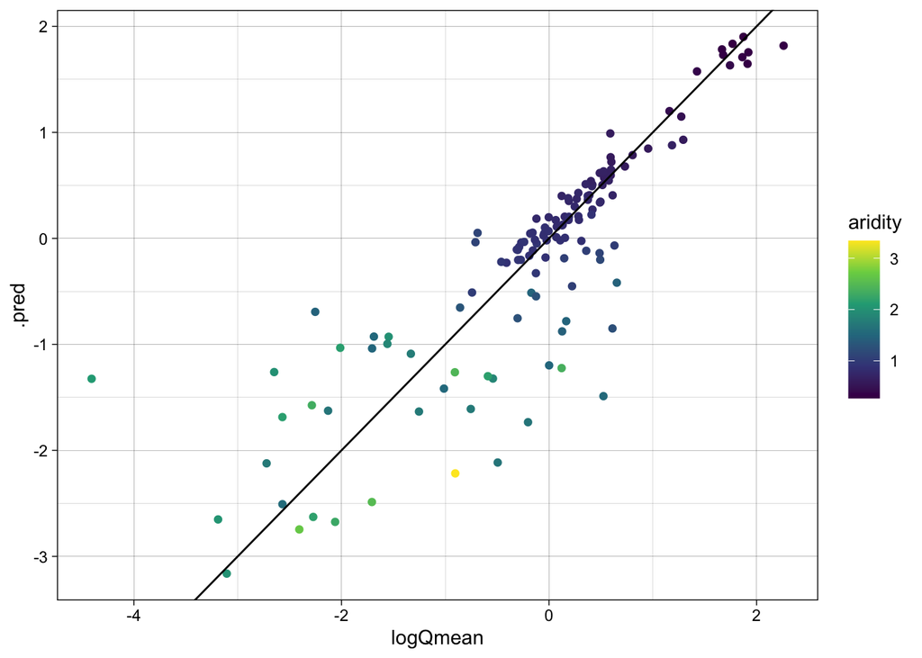

```r
ggplot(rf_data, aes(x = logQmean, y = .pred, colour = aridity)) +
  scale_color_viridis_c() +
  geom_point() +
  geom_abline() +
  theme_linedraw()
```

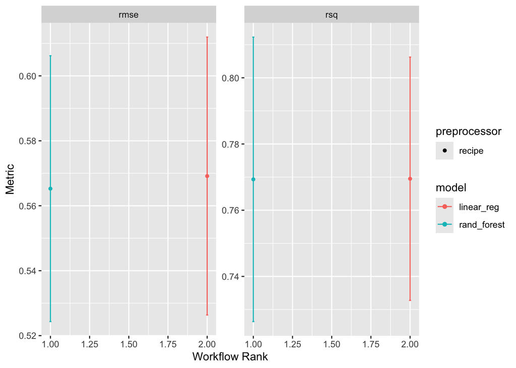

```r
# Workflowset approach
wf <- workflow_set(list(rec), list(lm_model, rf_model)) %>%
  workflow_map('fit_resamples', resamples = camels_cv)

autoplot(wf)
```

```r
rank_results(wf, rank_metric = "rsq", select_best = TRUE)
```

```
# A tibble: 4 × 9
  wflow_id          .config .metric  mean std_err     n preprocessor model  rank
  <chr>             <chr>   <chr>   <dbl>   <dbl> <int> <chr>        <chr> <int>
1 recipe_linear_reg Prepro… rmse    0.569  0.0260    10 recipe       line…     1
2 recipe_linear_reg Prepro… rsq     0.770  0.0223    10 recipe       line…     1
3 recipe_rand_fore… Prepro… rmse    0.565  0.0249    10 recipe       rand…     2
4 recipe_rand_fore… Prepro… rsq     0.769  0.0261    10 recipe       rand…     2
```

## Question 3

### Build a `xgboost` (engine) regression (mode) model using `boost_tree`

```r
xgb_mod <- boost_tree(mode = "regression",
                      trees = 1000) %>%
  set_engine('xgboost')
```

### Build a neural network model using the `nnet` engine from the `baguette` package using the `bag_mlp` function

```r
nn_mod <- bag_mlp() %>%
  set_engine('nnet') %>%
  set_mode("regression")

# Adding to the above workflow
xgb_wf <- workflow() %>%
  add_recipe(rec) %>%
  add_model(xgb_mod) %>%
  fit(data = camels_train) %>%
  augment(camels_train)

nn_wf <- workflow() %>%
  add_recipe(rec) %>%
  add_model(nn_mod) %>%
  fit(data = camels_train) %>%
  augment(camels_train)
```

### Evaluate the model and compare it to the linear and random forest models

```r
metrics(xgb_wf, truth = logQmean, estimate = .pred)
```

```
# A tibble: 3 × 3
  .metric .estimator .estimate
  <chr>   <chr>          <dbl>
1 rmse    standard     0.00292
2 rsq     standard     1.00
3 mae     standard     0.00211
```

```r
metrics(nn_wf, truth = logQmean, estimate = .pred)
```

```
# A tibble: 3 × 3
  .metric .estimator .estimate
  <chr>   <chr>          <dbl>
1 rmse    standard       0.478
2 rsq     standard       0.837
3 mae     standard       0.299
```

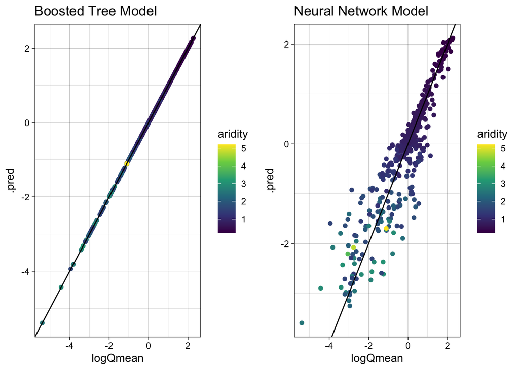

```r
plot1 <- ggplot(xgb_wf, aes(x = logQmean, y = .pred, colour = aridity)) +
  scale_color_viridis_c() +
  geom_point() +
  geom_abline() +
  labs(title = "Boosted Tree Model") +
  theme_linedraw()

plot2 <- ggplot(nn_wf, aes(x = logQmean, y = .pred, colour = aridity)) +
  scale_color_viridis_c() +
  geom_point() +
  geom_abline() +
  labs(title = "Neural Network Model") +
  theme_linedraw()

ggarrange(plot1, plot2)
```

As shown in the above plots, the boosted tree model and neural network model produced different results. This is similar to the previous evaluations on the linear regression model and random forest model which also produced different results. I would move forward with the boosted tree model because its results are directly on the 1:1 line.

## Question 4 (Build Your Own)

### Data Splitting

```r
# Set a seed for reproducible
set.seed(123456)

# Create an initial split with 75% used for training and 25% for testing
split <- initial_split(camels, prop = 0.75)

# Extract your training and testing sets
train_camels <- training(split)
glimpse(train_camels)
```

```
Rows: 503
Columns: 59
$ gauge_id             <chr> "01548500", "03357350", "01451800", "02118500", "…
$ p_mean               <dbl> 3.153346, 3.220156, 3.503207, 3.497721, 3.508962,…
$ pet_mean             <dbl> 2.271782, 2.529923, 2.418851, 2.854343, 2.566778,…
$ p_seasonality        <dbl> 0.17916389, 0.19294173, 0.10670771, 0.06450132, 0…
$ frac_snow            <dbl> 0.202088630, 0.070238198, 0.128362666, 0.04137083…
$ aridity              <dbl> 0.7204355, 0.7856524, 0.6904675, 0.8160581, 0.731…
$ high_prec_freq       <dbl> 18.10, 22.60, 23.80, 22.35, 21.45, 22.20, 21.55, …
$ high_prec_dur        <dbl> 1.120743, 1.167959, 1.233161, 1.238227, 1.194986,…
$ high_prec_timing     <chr> "jja", "jja", "son", "mam", "mam", "djf", "mam", …
$ low_prec_freq        <dbl> 221.00, 253.55, 254.25, 250.15, 250.60, 257.35, 2…
$ low_prec_dur         <dbl> 3.177570, 4.183993, 4.188633, 4.556466, 4.111567,…
$ low_prec_timing      <chr> "son", "son", "son", "son", "son", "son", "son", …
$ geol_1st_class       <chr> "Siliciclastic sedimentary rocks", "Mixed sedimen…
```

[output cut: 46 more lines]

```r
test_camels <- testing(split)
glimpse(test_camels)
```

```
Rows: 168
Columns: 59
$ gauge_id             <chr> "01055000", "01121000", "01134500", "01139800", "…
$ p_mean               <dbl> 3.494183, 3.719591, 3.467413, 3.303515, 3.420860,…
$ pet_mean             <dbl> 2.093235, 2.301408, 2.091698, 2.127185, 2.157740,…
$ p_seasonality        <dbl> 0.167229041, 0.004098324, 0.228672353, 0.22557908…
$ frac_snow            <dbl> 0.30604885, 0.15422715, 0.28058209, 0.26232897, 0…
$ aridity              <dbl> 0.5990628, 0.6187263, 0.6032446, 0.6439157, 0.630…
$ high_prec_freq       <dbl> 19.15, 21.50, 15.85, 19.45, 19.05, 19.95, 20.40, …
$ high_prec_dur        <dbl> 1.167683, 1.197772, 1.152727, 1.164671, 1.133929,…
$ high_prec_timing     <chr> "son", "son", "jja", "jja", "jja", "son", "son", …
$ low_prec_freq        <dbl> 224.85, 241.70, 201.10, 225.55, 225.15, 226.35, 2…
$ low_prec_dur         <dbl> 3.378663, 3.721324, 2.842403, 3.278343, 3.315906,…
$ low_prec_timing      <chr> "mam", "son", "mam", "mam", "mam", "son", "son", …
$ geol_1st_class       <chr> "Siliciclastic sedimentary rocks", "Metamorphics"…
```

[output cut: 46 more lines]

```r
# Build a 10-fold CV dataset as well
cv_folds <- vfold_cv(train_camels, v = 10)

cv_folds
```

```
#  10-fold cross-validation
# A tibble: 10 × 2
   splits           id
   <list>           <chr>
 1 <split [452/51]> Fold01
 2 <split [452/51]> Fold02
 3 <split [452/51]> Fold03
 4 <split [453/50]> Fold04
 5 <split [453/50]> Fold05
 6 <split [453/50]> Fold06
 7 <split [453/50]> Fold07
 8 <split [453/50]> Fold08
 9 <split [453/50]> Fold09
10 <split [453/50]> Fold10
```

### Recipe

```r
# Define a formula you want to use to predict logQmean
formula <- logQmean ~ p_mean + aridity + high_prec_dur
```

#### Describe in words why you are choosing the formula you are. Consult the downloaded PDF for the data to help you make this decision.

I chose to use aridity, p_mean, and high_prec_dur in my formula because I believe these three factors have significant influence on the mean daily discharge. Aridity (`aridity`) represents the dryness of an environment and environments that are more arid will in turn have a lower `logQmean`. Precipitation (`p_mean`) adds water to the overall discharge system, and going along with that, `high_prec_dur` will influence the `logQmean` because more precipitation means more daily discharge.

```r
# Build a recipe that you feel handles the predictors chosen well
train_camels <- na.omit(train_camels)

rec <- recipe(logQmean ~  p_mean + aridity + high_prec_dur, data = train_camels) %>%
  step_log(all_predictors()) %>%
  step_interact(terms = ~ aridity:p_mean) %>%
  step_naomit(all_predictors(), all_outcomes()) %>%
  step_zv(all_predictors())

rec_prep <- prep(rec, training = train_camels)
baked_data <- bake(rec_prep, new_data = NULL)
```

### Define 3 Models

```r
# Define a random forest model using the rand_forest function. Set the engine to ranger and the mode to regression
rf_mod2 <- rand_forest() %>%
  set_engine('ranger') %>%
  set_mode("regression")

# Define two other models of your choice
lm_mod2 <- linear_reg() %>%
  set_engine('lm') %>%
  set_mode("regression")

xgb_mod2 <- boost_tree() %>%
  set_engine('xgboost') %>%
  set_mode("regression")
```

### Workflow set()

```r
# With your pre-processing steps and models defined, you can now build a workflow_set object to fit and evaluate your models. This will allow you to compare the performance of different models on the same data.

# Create a workflow object, add the recipe, add the model(s)
rf_wf2 <- workflow() %>%
  add_recipe(rec) %>%
  add_model(rf_mod2)

lm_wf2 <- workflow() %>%
  add_recipe(rec) %>%
  add_model(lm_mod2)

xgb_wf2 <- workflow() %>%
  add_recipe(rec) %>%
  add_model(xgb_mod2)

# Fit the model to the resamples
rf_res <- fit_resamples(rf_wf2, resamples = cv_folds)
lm_res <- fit_resamples(lm_wf2, resamples = cv_folds)
xgb_res <- fit_resamples(xgb_wf2, resamples = cv_folds)
```

### Evaluation

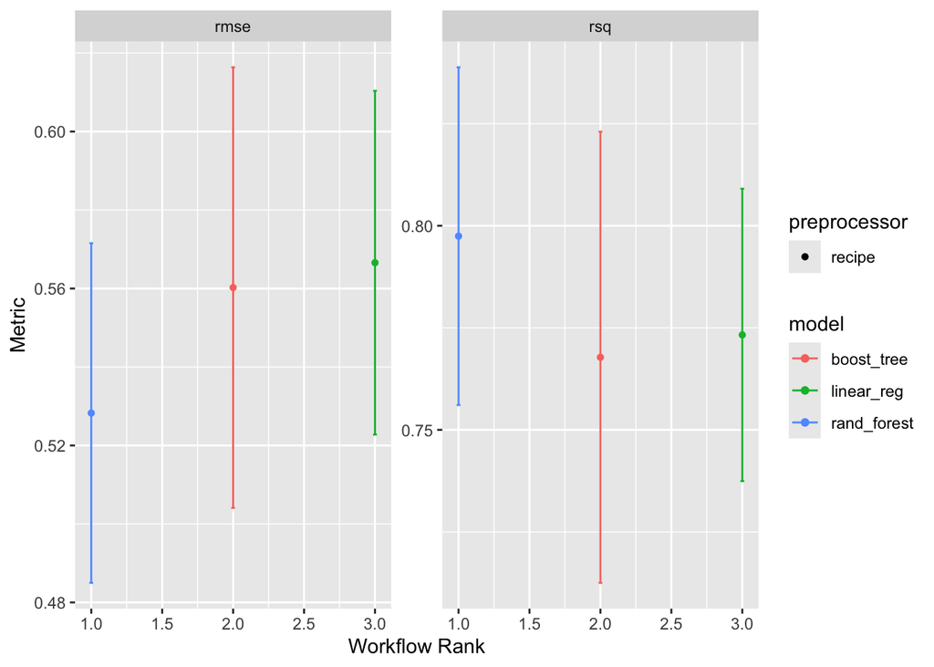

```r
# Use autoplot and rank_results to compare the models.
wf <- workflow_set(list(rec), list(rf_mod2, lm_mod2, xgb_mod2)) %>%
  workflow_map('fit_resamples', resamples = camels_cv)

autoplot(wf)
```

```r
rank_results(wf, rank_metric = "rsq", select_best = TRUE)
```

```
# A tibble: 6 × 9
  wflow_id          .config .metric  mean std_err     n preprocessor model  rank
  <chr>             <chr>   <chr>   <dbl>   <dbl> <int> <chr>        <chr> <int>
1 recipe_rand_fore… Prepro… rmse    0.528  0.0263    10 recipe       rand…     1
2 recipe_rand_fore… Prepro… rsq     0.797  0.0252    10 recipe       rand…     1
3 recipe_linear_reg Prepro… rmse    0.567  0.0266    10 recipe       line…     2
4 recipe_linear_reg Prepro… rsq     0.773  0.0218    10 recipe       line…     2
5 recipe_boost_tree Prepro… rmse    0.560  0.0341    10 recipe       boos…     3
6 recipe_boost_tree Prepro… rsq     0.768  0.0336    10 recipe       boos…     3
```

### Extract and Evaluate

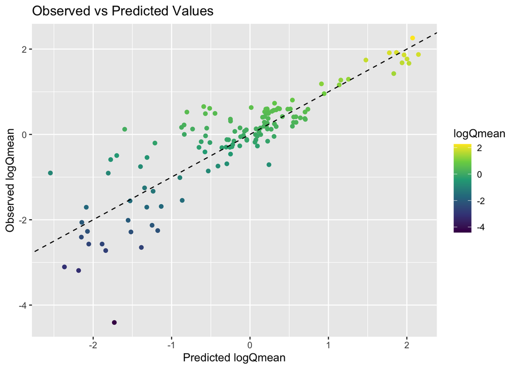

```r
# Now that you found your favorite model, lets see how it does on the test data!

# Build a workflow (not workflow set) with your favorite model, recipe, and training data. Use fit to fit all training data to the model
wf_final <- workflow() %>%
  add_recipe(rec) %>%
  add_model(lm_mod2) %>%
  fit(data = train_camels)

# Use augment to make predictions on the test data
wf_data_final <- augment(wf_final, new_data = camels_test)

# Create a plot of the observed vs predicted values with clear title, axis labels, and a compelling color scale
ggplot(wf_data_final, aes(x = .pred, y = logQmean, colour = logQmean)) +
  geom_point() +
  geom_abline(slope = 1, intercept = 0, color = "black", linetype = "dashed") +
  labs(title = "Observed vs Predicted Values",
       x = "Predicted logQmean",
       y = "Observed logQmean") +
  scale_color_viridis_c()
```

#### Describe what you think of the results!

Looking at the plot, the results are pretty accurate. The plotted observed vs. predicted values lie relatively close to the 1:1 line, which means the predictions have a strong accuracy.